# NBA Data Analysis

2024-04-23

# Background

The data consists of all NBA final score and boxscore at half time for 2023-24 regular season. The goal is to use boxscore information at halftime to predict the final score. The data Source is nba_api (https://github.com/swar/nba_api), and the data were pulled and cleaned separately using Python.

### Attributes:

- GAME_ID: id of the game
- team: the boxscore information of the team
- against: the opposing team
- s_: all information for starters
- b_: all information for bench players
- minutes: minutes played
- PTS_final: final score by team at end of game
- home_away: team is at home or away
- PTS_ht: team score at halftime
- PTS_ht_opp: opponent score at halftime

### Set up environment

```
##    GAME_ID team against s_minutes s_FGM s_FGA s_3PM s_3PA s_FTM s_FTA s_OREB
## 1 22300001  IND     CLE  76.88333    18    33     6    11     6     8      3
## 2 22300001  CLE     IND  70.66667    16    30     2     9     4     5      3
## 3 22300002  NYK     MIL  87.78333    13    39     5    15     7    12     12
## 4 22300002  MIL     NYK  74.35000    12    25     5     8     8    10      3
## 5 22300003  MIA     WAS  73.41667    13    25     4     7     6     6      0
## 6 22300003  WAS     MIA  77.98333    16    28     7    11     3     5      1
##   s_DREB s_AST s_STL s_BLK s_TO s_FOUL b_FGM b_FGA b_3PM b_3PA b_FTM b_FTA
## 1     13    15     4     0    5      4     8    13     3     5     3     6
## 2      8    11     4     4    7      7     6    15     2     7     1     2
## 3     15     7     3     1    3      9     3    12     2     6     0     0
## 4     10     9     0     5    6      3     7    17     5    10     0     0
## 5     13    12     2     0    7      5    11    15     2     4     0     0
## 6      9     9     2     1    8      7     6    11     0     3     0     2
##   b_OREB b_DREB b_AST b_STL b_BLK b_TO b_FOUL home_away PTS_ht PTS_ht_opp
## 1      0      7     5     1     3    4      3      home     70         53
## 2      0      6     4     2     1    1      4      away     53         70
## 3      2      5     1     0     0    3      1      away     46         56
## 4      0      6     3     3     0    0      3      home     56         46
## 5      3      3     7     2     1    2      1      home     60         54
## 6      1      4     7     1     0    3      0      away     54         60
##   PTS_final
## 1       121
## 2       116
## 3       105
## 4       110
## 5       121
## 6       114
```

### Clean and reformat data

```r
# Add s_2PA, b_2PM, and b_2PA and remove s_FGM, s_FGA, b_FGM, and b_FGA since FG includes both 2 pointers and 3 pointers
# s_2PM is not added because it'll cause multicolliearity
data$s_2PA <- data$s_FGA - data$s_3PA
data$b_2PM <- data$b_FGM - data$b_3PM
data$b_2PA <- data$b_FGA - data$b_3PA

# Create dummy variable, home, for home_away, and drop home_away
# Also drop GAME_ID
data$home_away <- as.factor(data$home_away)
home = rep(1, nrow(data))
home[as.numeric(data$home_away)==1] = 0
data$home <- home
data = subset(data, select = -c(s_FGM, s_FGA, b_FGM, b_FGA, home_away, GAME_ID))

data$team <- as.factor(data$team)
data$against <- as.factor(data$against)

# Move PTS_final to last column
data$PTS_final1 = data$PTS_final
data = subset(data, select = -PTS_final)
names(data)[names(data) == "PTS_final1"] <- "PTS_final"
```

```r
# Splitting training and testing data
set.seed(100)

# Dividing the dataset into training and testing datasets
testRows = sample(nrow(data),0.2*nrow(data))
test = data[testRows, ]
train = data[-testRows, ]
# Reindex dataframes
rownames(test) <- 1:nrow(test)
rownames(train) <- 1:nrow(train)

attach(train)
```

## Exploratory Data Analysis (EDA)

### Correlation Plot

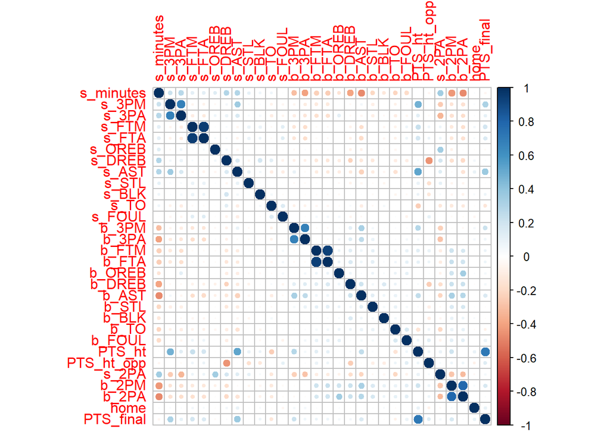

```r
cor <- cor(subset(train, select=-c(team, against)))
corrplot(cor)
```

### Histogram of Variables - Starter Stats

Red means heavy tail

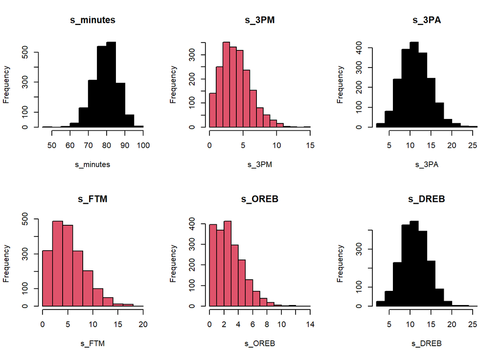

```r
# Histograms of variables - starters
par(mfrow = c(2, 3))
hist(s_minutes, main='s_minutes', col=1)
hist(s_3PM, main='s_3PM', col=2)
hist(s_3PA, main='s_3PA', col=1)
hist(s_FTM, main='s_FTM', col=2)
hist(s_OREB, main='s_OREB', col=2)
hist(s_DREB, main='s_DREB', col=1)
```

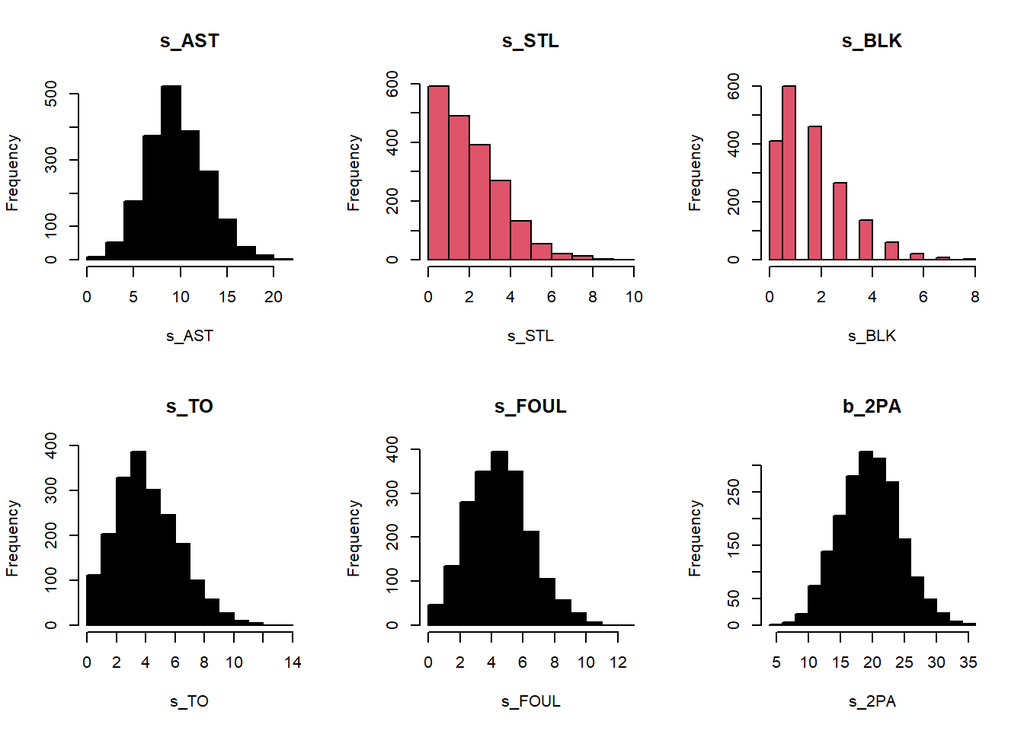

```r
hist(s_AST, main='s_AST', col=1)
hist(s_STL, main='s_STL', col=2)
hist(s_BLK, main='s_BLK', col=2)
hist(s_TO, main='s_TO', col=1)
hist(s_FOUL, main='s_FOUL', col=1)
hist(s_2PA, main='b_2PA', col=1)
```

Histograms in red shows heavy tails, and the variables are s_3PM, s_FTM, s_OREB, s_STL, and s_BLK.

### Histogram of Variables - Bench Stats

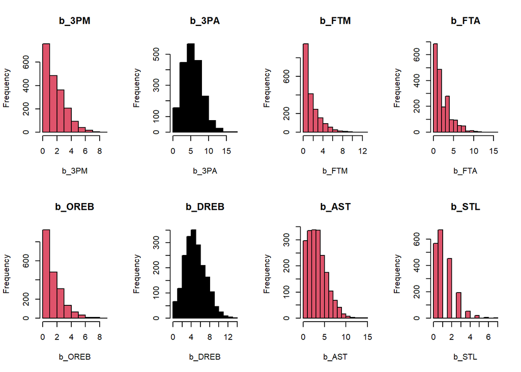

```r
# Histograms of variables - bench
par(mfrow = c(2, 4))
hist(b_3PM, main='b_3PM', col=2)
hist(b_3PA, main='b_3PA', col=1)
hist(b_FTM, main='b_FTM', col=2)
hist(b_FTA, main='b_FTA', col=2)
hist(b_OREB, main='b_OREB', col=2)
hist(b_DREB, main='b_DREB', col=1)
hist(b_AST, main='b_AST', col=2)
hist(b_STL, main='b_STL', col=2)
```

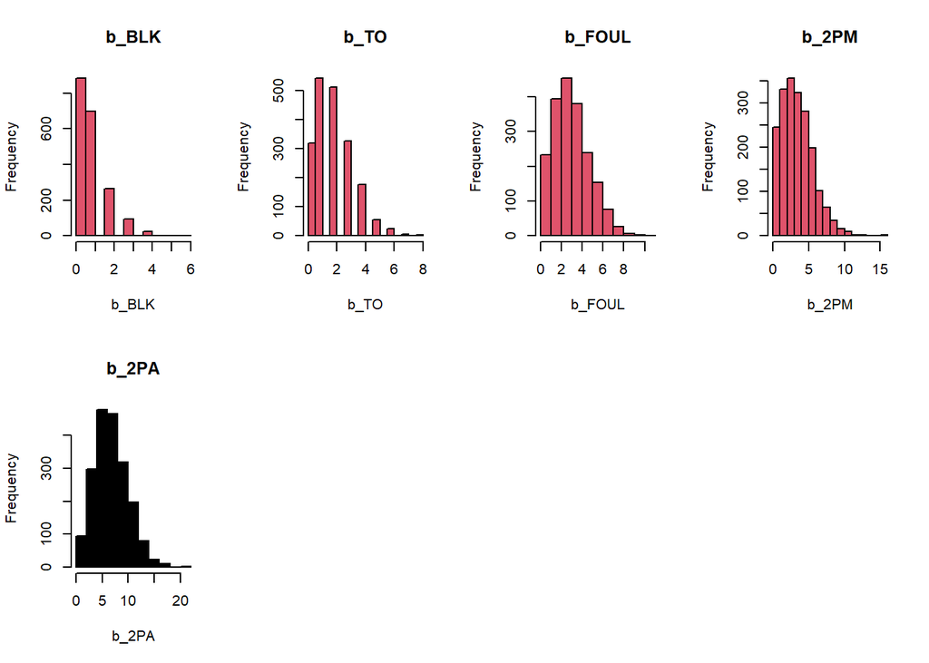

```r
hist(b_BLK, main='b_BLK', col=2)
hist(b_TO, main='b_TO', col=2)
hist(b_FOUL, main='b_FOUL', col=2)
hist(b_2PM, main='b_2PM', col=2)
hist(b_2PA, main='b_2PA', col=1)
```

Most stats for bench players have heavy tails (in red). The exceptions are 3PA, DREB, and 2PA

### Histogram of Variables - Total Score

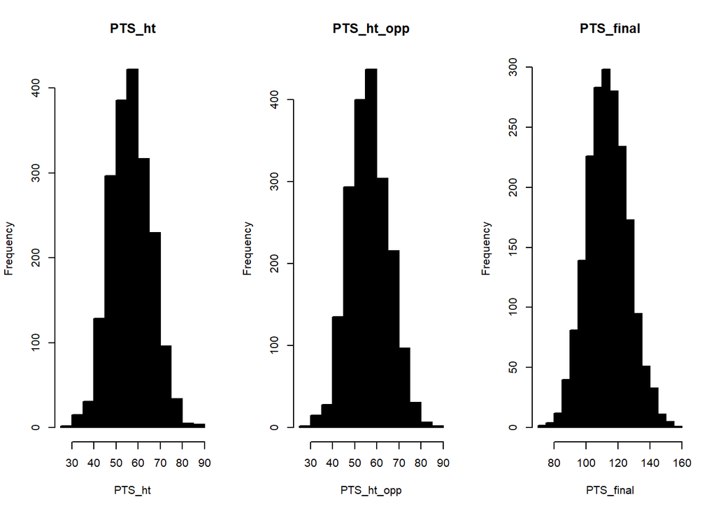

```r
# Histogram of response variable and score at halftime
par(mfrow = c(1, 3))
hist(PTS_ht, main='PTS_ht', col=1)
hist(PTS_ht_opp, main='PTS_ht_opp', col=1)
hist(PTS_final, main='PTS_final', col=1)
```

All three are approximately normally distributed.

### Scatterplot of predicting vs. response variables

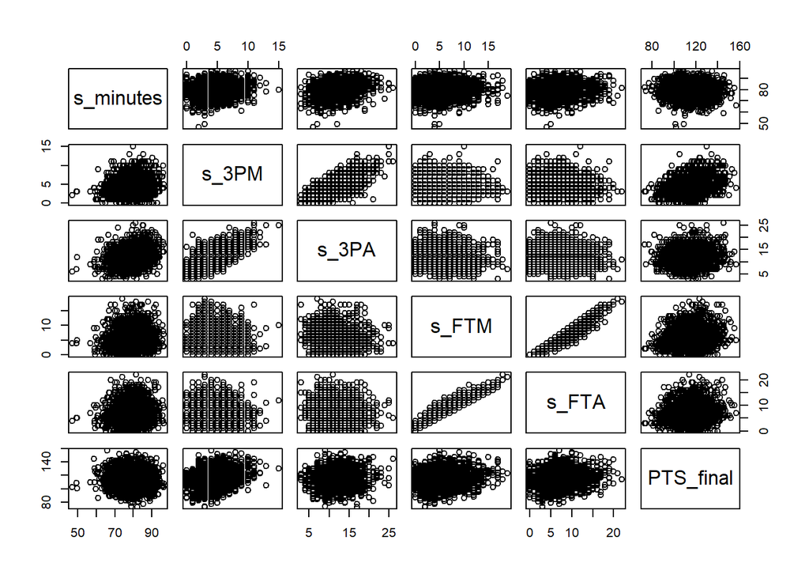

```r
# Scatterplots of predicting variables vs. PTS_final (starter)
res_index = dim(train)[2]
pairs(train[,c(3:7, res_index)])
```

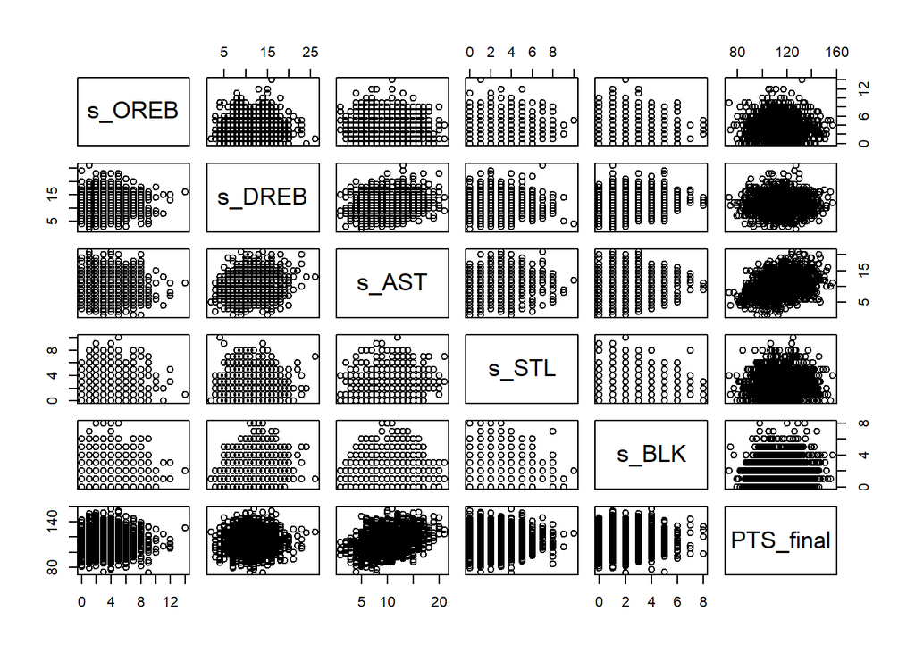

```r
pairs(train[,c(8:12, res_index)])
```

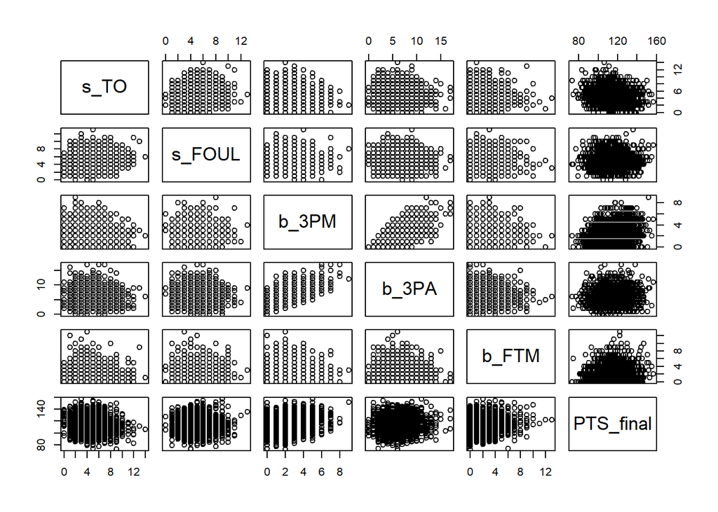

```r
pairs(train[,c(13:17, res_index)])
```

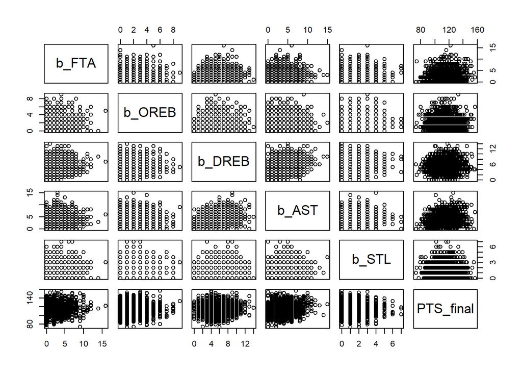

```r
pairs(train[,c(18:22, res_index)])
```

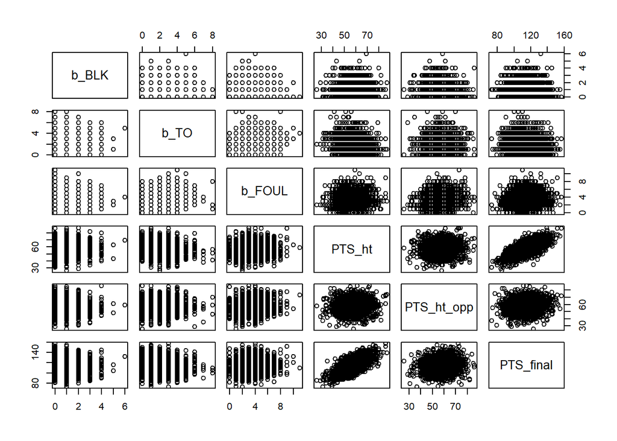

```r
pairs(train[,c(23:27, res_index)])
```

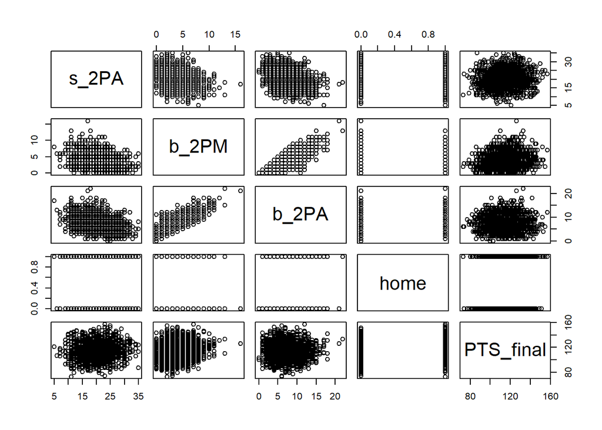

```r
pairs(train[,c(28:31, res_index)])
```

## Variable Selection

We will utilize stepwise selection (backward and forward) with BIC as the parameter, mallow’s cp, LASSO, and elastic net to select the “best” regression model.

### Stepwise Regression

```r
# Stepwise regression with BIC
model_min = lm(PTS_final ~ PTS_ht, data=train) # Include PTS_ht as it's an obvious variable to include in the model
model_full = lm(PTS_final ~ . -team -against, data=train) # Exclude teams for simplicity

# Forward selection with BIC
model_forward = step(model_min, scope=list(lower=model_min,  upper=model_full), direction="forward", trace=F, k=log(nrow(train)))
summary(model_forward)
```

```
##
## Call:
## lm(formula = PTS_final ~ PTS_ht + PTS_ht_opp + b_DREB + s_DREB,
##     data = train)
##
## Residuals:
##     Min      1Q  Median      3Q     Max
## -27.790  -6.199  -0.167   6.128  32.144
##
## Coefficients:
##             Estimate Std. Error t value Pr(>|t|)
## (Intercept) 39.76209    2.59868  15.301  < 2e-16 ***
## PTS_ht       0.99333    0.02258  43.997  < 2e-16 ***
## PTS_ht_opp   0.20388    0.02771   7.358 2.72e-13 ***
## b_DREB       0.47700    0.09704   4.915 9.60e-07 ***
## s_DREB       0.29333    0.07441   3.942 8.35e-05 ***
## ---
## Signif. codes:  0 '***' 0.001 '**' 0.01 '*' 0.05 '.' 0.1 ' ' 1
##
## Residual standard error: 8.905 on 1963 degrees of freedom
## Multiple R-squared:  0.5205, Adjusted R-squared:  0.5196
## F-statistic: 532.8 on 4 and 1963 DF,  p-value: < 2.2e-16
```

```r
# Backward selection
model_backward = step(model_full, scope=list(lower=model_min,  upper=model_full), direction="backward", trace=F, k=log(nrow(train)))
summary(model_backward)
```

```
##
## Call:
## lm(formula = PTS_final ~ PTS_ht + PTS_ht_opp, data = train)
##
## Residuals:
##      Min       1Q   Median       3Q      Max
## -27.5548  -6.1626  -0.0121   5.9537  31.5976
##
## Coefficients:
##             Estimate Std. Error t value Pr(>|t|)
## (Intercept) 49.43596    1.77290  27.884  < 2e-16 ***
## PTS_ht       1.00755    0.02256  44.660  < 2e-16 ***
## PTS_ht_opp   0.12411    0.02284   5.433 6.22e-08 ***
## ---
## Signif. codes:  0 '***' 0.001 '**' 0.01 '*' 0.05 '.' 0.1 ' ' 1
##
## Residual standard error: 8.967 on 1965 degrees of freedom
## Multiple R-squared:  0.5134, Adjusted R-squared:  0.5129
## F-statistic:  1037 on 2 and 1965 DF,  p-value: < 2.2e-16
```

```r
sprintf("model_forward includes: %s", paste(all.vars(formula(model_forward))[-1], collapse=', '))
```

```
## [1] "model_forward includes: PTS_ht, PTS_ht_opp, b_DREB, s_DREB"
```

```r
sprintf("model_backward includes: %s", paste(all.vars(formula(model_backward))[-1], collapse=', '))
```

```
## [1] "model_backward includes: PTS_ht, PTS_ht_opp"
```

BIC is used for variable selection because the goal of the model is mostly for prediction. Interestingly, only 1 additional variable (PTS_ht_opp) is selected by model_backward, and 3 additional variables are selected by model_forward.

### Mallow’s cp

```r
# Mallows Cp
out = leaps(train[, c(3:31)], train[, res_index], method = "Cp", strictly.compatible = F, nbest = 1)
cbind(as.matrix(out$which), out$Cp)
```

```
##    s_minutes s_3PM s_3PA s_FTM s_FTA s_OREB s_DREB s_AST s_STL s_BLK s_TO
## 1          0     0     0     0     0      0      0     0     0     0    0
## 2          0     0     0     0     0      0      0     0     0     0    0
## 3          0     0     0     0     0      0      0     0     0     0    0
## 4          0     0     0     0     0      0      1     0     0     0    0
## 5          0     0     0     0     0      0      1     0     0     0    0
## 6          0     0     0     0     0      0      1     0     0     0    0
## 7          0     0     0     0     0      0      1     0     0     0    0
## 8          0     0     0     0     0      0      1     0     0     1    0
## 9          0     1     1     0     0      0      1     0     0     0    1
## 10         0     1     1     0     0      0      1     0     0     0    1
## 11         0     1     1     0     0      0      1     0     0     0    1
## 12         1     1     1     0     0      0      1     0     0     0    1
## 13         1     1     1     0     0      0      1     0     0     0    1
## 14         1     1     1     0     0      0      1     0     0     0    1
```

[output cut: 75 more lines]

```r
best.model=which(out$Cp==min(out$Cp))
mellow_coef = cbind(as.matrix(out$which), out$Cp)[best.model,]
print(names(mellow_coef[mellow_coef==1]))
```

```
##  [1] "s_minutes"  "s_3PM"      "s_3PA"      "s_DREB"     "s_BLK"
##  [6] "s_TO"       "b_FTM"      "b_OREB"     "b_DREB"     "b_AST"
## [11] "b_STL"      "b_FOUL"     "PTS_ht"     "PTS_ht_opp" "home"
```

```r
# Mallows Cp
model_cp = lm(PTS_final ~ s_minutes+s_3PM+s_3PA+s_DREB+s_BLK+s_TO+b_FTM+b_OREB+
b_DREB+b_AST+b_STL+b_FOUL+PTS_ht+PTS_ht_opp+home, data=train)
summary(model_cp)
```

```
##
## Call:
## lm(formula = PTS_final ~ s_minutes + s_3PM + s_3PA + s_DREB +
##     s_BLK + s_TO + b_FTM + b_OREB + b_DREB + b_AST + b_STL +
##     b_FOUL + PTS_ht + PTS_ht_opp + home, data = train)
##
## Residuals:
##     Min      1Q  Median      3Q     Max
## -26.287  -6.176  -0.067   5.916  31.676
##
## Coefficients:
##             Estimate Std. Error t value Pr(>|t|)
## (Intercept) 44.01826    4.43519   9.925  < 2e-16 ***
## s_minutes   -0.09287    0.04104  -2.263 0.023767 *
## s_3PM       -0.37771    0.14612  -2.585 0.009815 **
## s_3PA        0.21041    0.08415   2.501 0.012483 *
## s_DREB       0.23364    0.07861   2.972 0.002994 **
## s_BLK        0.20264    0.14206   1.426 0.153911
## s_TO         0.20212    0.09777   2.067 0.038828 *
## b_FTM       -0.16932    0.10831  -1.563 0.118157
## b_OREB       0.27602    0.13751   2.007 0.044855 *
## b_DREB       0.36843    0.10515   3.504 0.000469 ***
## b_AST       -0.17895    0.10406  -1.720 0.085647 .
## b_STL       -0.30209    0.17844  -1.693 0.090622 .
## b_FOUL       0.17194    0.11697   1.470 0.141744
## PTS_ht       1.04875    0.02964  35.386  < 2e-16 ***
## PTS_ht_opp   0.18448    0.02866   6.437 1.53e-10 ***
## home         1.01914    0.40260   2.531 0.011438 *
## ---
## Signif. codes:  0 '***' 0.001 '**' 0.01 '*' 0.05 '.' 0.1 ' ' 1
##
## Residual standard error: 8.844 on 1952 degrees of freedom
## Multiple R-squared:  0.5298, Adjusted R-squared:  0.5262
## F-statistic: 146.6 on 15 and 1952 DF,  p-value: < 2.2e-16
```

15 variables were selected using Mallow’s Cp which is more than both forward (4) and backward (2) selection.

### LASSO

```r
# LASSO - variable selection

# Set a seed for reproducibility
set.seed(1)

# Set predictors and response to correct format
x.train <- model.matrix(PTS_final ~ ., train[,c(3:res_index)])
y.train <- train$PTS_final

# Use cross validation to find optimal lambda
cv.lasso <- cv.glmnet(x.train, y.train, alpha = 1)

# Train Lasso and display coefficients with optimal lambda
lasso.model <- glmnet(x.train, y.train, alpha = 1)
coef(lasso.model, cv.lasso$lambda.min)
```

```
## 31 x 1 sparse Matrix of class "dgCMatrix"
##                      s1
## (Intercept) 42.30401330
## (Intercept)  .
## s_minutes   -0.05583093
## s_3PM       -0.24766986
## s_3PA        0.24703191
## s_FTM        .
## s_FTA        0.10416356
## s_OREB      -0.17185546
## s_DREB       0.15378300
## s_AST        0.01049473
## s_STL       -0.19457794
## s_BLK        0.17348570
## s_TO         0.24628382
## s_FOUL       .
## b_3PM        0.05695461
## b_3PA        0.14531888
## b_FTM       -0.07168955
## b_FTA        .
## b_OREB       0.20625681
## b_DREB       0.29562154
## b_AST       -0.13207361
## b_STL       -0.33779052
## b_BLK       -0.16041315
## b_TO         0.19156654
## b_FOUL       0.13720354
## PTS_ht       1.01264397
## PTS_ht_opp   0.14609235
## s_2PA        0.07886736
## b_2PM        0.14040377
## b_2PA        .
## home         0.91167592
```

With LASSO, it removed s_FTM, s_FOUL, b_FTA, and b_2PA. A new model will be fit below to find coefficients. Furthermore, since multicollinearity may be a concern with our data, elastic net should also be attempted to fit model.

```r
# LASSO - fit model
model_lasso = lm(PTS_final ~ . -s_FTM -s_FOUL -b_FTA -b_2PA, train[,c(3:res_index)])
summary(model_lasso)
```

```
##
## Call:
## lm(formula = PTS_final ~ . - s_FTM - s_FOUL - b_FTA - b_2PA,
##     data = train[, c(3:res_index)])
##
## Residuals:
##     Min      1Q  Median      3Q     Max
## -26.467  -6.149  -0.083   5.832  31.781
##
## Coefficients:
##             Estimate Std. Error t value Pr(>|t|)
## (Intercept) 40.73513    5.03321   8.093 1.01e-15 ***
## s_minutes   -0.07038    0.04692  -1.500 0.133790
## s_3PM       -0.27813    0.17837  -1.559 0.119097
## s_3PA        0.34154    0.10335   3.305 0.000968 ***
## s_FTA        0.13737    0.07253   1.894 0.058373 .
## s_OREB      -0.25213    0.12155  -2.074 0.038180 *
## s_DREB       0.14229    0.08835   1.610 0.107452
## s_AST        0.01391    0.09124   0.152 0.878818
## s_STL       -0.24666    0.13732  -1.796 0.072616 .
## s_BLK        0.18428    0.14254   1.293 0.196231
## s_TO         0.31430    0.10976   2.864 0.004233 **
## b_3PM        0.09905    0.21826   0.454 0.649998
## b_3PA        0.20154    0.12373   1.629 0.103509
## b_FTM       -0.06693    0.12066  -0.555 0.579192
## b_OREB       0.17932    0.14586   1.229 0.219070
## b_DREB       0.28844    0.11134   2.591 0.009648 **
## b_AST       -0.16490    0.11835  -1.393 0.163674
## b_STL       -0.39431    0.18277  -2.157 0.031102 *
## b_BLK       -0.20928    0.21799  -0.960 0.337161
## b_TO         0.26937    0.15899   1.694 0.090386 .
## b_FOUL       0.14291    0.11865   1.205 0.228541
## PTS_ht       1.00994    0.04993  20.225  < 2e-16 ***
## PTS_ht_opp   0.14008    0.03335   4.200 2.79e-05 ***
## s_2PA        0.15388    0.09253   1.663 0.096476 .
## b_2PM        0.22752    0.15402   1.477 0.139764
## home         0.97185    0.40486   2.400 0.016468 *
## ---
## Signif. codes:  0 '***' 0.001 '**' 0.01 '*' 0.05 '.' 0.1 ' ' 1
##
## Residual standard error: 8.842 on 1942 degrees of freedom
## Multiple R-squared:  0.5324, Adjusted R-squared:  0.5264
## F-statistic: 88.44 on 25 and 1942 DF,  p-value: < 2.2e-16
```

### Elastic Net

```r
# Elastic Net - Variable Selection

# Set a seed for reproducibility
set.seed(1)

# Set predictors and response to correct format
x.train <- model.matrix(PTS_final ~ ., train[,c(3:res_index)])
y.train <- train$PTS_final

# Use cross validation to find optimal lambda
cv.elasticnet <- cv.glmnet(x.train, y.train, alpha = 0.5)

# Train Lasso and display coefficients with optimal lambda
elasticnet.model <- glmnet(x.train, y.train, alpha = 0.5)
coef(elasticnet.model, cv.elasticnet$lambda.min)
```

```
## 31 x 1 sparse Matrix of class "dgCMatrix"
##                      s1
## (Intercept) 42.24859266
## (Intercept)  .
## s_minutes   -0.05670792
## s_3PM       -0.21787986
## s_3PA        0.25304090
## s_FTM        .
## s_FTA        0.11689644
## s_OREB      -0.18224481
## s_DREB       0.15253545
## s_AST        0.02134734
## s_STL       -0.19815488
## s_BLK        0.17584878
## s_TO         0.24977178
## s_FOUL       .
## b_3PM        0.09127729
## b_3PA        0.14826053
## b_FTM       -0.05948801
## b_FTA        .
## b_OREB       0.20240188
## b_DREB       0.29423368
## b_AST       -0.12567169
## b_STL       -0.34092445
## b_BLK       -0.16416982
## b_TO         0.19642711
## b_FOUL       0.13873005
## PTS_ht       0.99953742
## PTS_ht_opp   0.14513593
## s_2PA        0.09513354
## b_2PM        0.16601447
## b_2PA        .
## home         0.91816107
```

With elastic net variable selection, same group of variables were removed as LASSO.

```r
# Elastic net - fit model
model_net = lm(PTS_final ~ . -s_FTM -s_FOUL -b_FTA -b_2PA, train[,c(3:res_index)])
summary(model_net)
```

```
##
## Call:
## lm(formula = PTS_final ~ . - s_FTM - s_FOUL - b_FTA - b_2PA,
##     data = train[, c(3:res_index)])
##
## Residuals:
##     Min      1Q  Median      3Q     Max
## -26.467  -6.149  -0.083   5.832  31.781
##
## Coefficients:
##             Estimate Std. Error t value Pr(>|t|)
## (Intercept) 40.73513    5.03321   8.093 1.01e-15 ***
## s_minutes   -0.07038    0.04692  -1.500 0.133790
## s_3PM       -0.27813    0.17837  -1.559 0.119097
## s_3PA        0.34154    0.10335   3.305 0.000968 ***
## s_FTA        0.13737    0.07253   1.894 0.058373 .
## s_OREB      -0.25213    0.12155  -2.074 0.038180 *
## s_DREB       0.14229    0.08835   1.610 0.107452
## s_AST        0.01391    0.09124   0.152 0.878818
## s_STL       -0.24666    0.13732  -1.796 0.072616 .
## s_BLK        0.18428    0.14254   1.293 0.196231
## s_TO         0.31430    0.10976   2.864 0.004233 **
## b_3PM        0.09905    0.21826   0.454 0.649998
## b_3PA        0.20154    0.12373   1.629 0.103509
## b_FTM       -0.06693    0.12066  -0.555 0.579192
## b_OREB       0.17932    0.14586   1.229 0.219070
## b_DREB       0.28844    0.11134   2.591 0.009648 **
## b_AST       -0.16490    0.11835  -1.393 0.163674
## b_STL       -0.39431    0.18277  -2.157 0.031102 *
## b_BLK       -0.20928    0.21799  -0.960 0.337161
## b_TO         0.26937    0.15899   1.694 0.090386 .
## b_FOUL       0.14291    0.11865   1.205 0.228541
## PTS_ht       1.00994    0.04993  20.225  < 2e-16 ***
## PTS_ht_opp   0.14008    0.03335   4.200 2.79e-05 ***
## s_2PA        0.15388    0.09253   1.663 0.096476 .
## b_2PM        0.22752    0.15402   1.477 0.139764
## home         0.97185    0.40486   2.400 0.016468 *
## ---
## Signif. codes:  0 '***' 0.001 '**' 0.01 '*' 0.05 '.' 0.1 ' ' 1
##
## Residual standard error: 8.842 on 1942 degrees of freedom
## Multiple R-squared:  0.5324, Adjusted R-squared:  0.5264
## F-statistic: 88.44 on 25 and 1942 DF,  p-value: < 2.2e-16
```

### Summary of Model Selection

```r
# Compare all selected models based on AIC, BIC, and adjusted R^2
n = nrow(train)
model_full_stats = list("Adj R2" = summary(model_full)$adj.r.squared, "AIC" = AIC(model_full, k=2), "BIC" = AIC(model_full, k=log(n)), "DF"=summary(model_full)$df[3])
model_forward_stats = list("Adj R2" = summary(model_forward)$adj.r.squared, "AIC" = AIC(model_forward, k=2), "BIC" = AIC(model_forward, k=log(n)), "DF"=summary(model_forward)$df[3])
model_backward_stats = list("Adj R2" = summary(model_backward)$adj.r.squared, "AIC" = AIC(model_backward, k=2), "BIC" = AIC(model_backward, k=log(n)), "DF"=summary(model_backward)$df[3])
model_cp_stats = list("Adj R2" = summary(model_cp)$adj.r.squared, "AIC" = AIC(model_cp, k=2), "BIC" = AIC(model_cp, k=log(n)), "DF"=summary(model_cp)$df[3])
model_lasso_stats = list("Adj R2" = summary(model_lasso)$adj.r.squared, "AIC" = AIC(model_lasso, k=2), "BIC" = AIC(model_lasso, k=log(n)), "DF"=summary(model_lasso)$df[3])
model_net_stats = list("Adj R2" = summary(model_net)$adj.r.squared, "AIC" = AIC(model_net, k=2), "BIC" = AIC(model_net, k=log(n)), "DF"=summary(model_net)$df[3])
model_compare = rbind(model_full_stats, model_forward_stats, model_backward_stats, model_cp_stats, model_lasso_stats, model_net_stats)
model_compare
```

```
##                      Adj R2    AIC      BIC      DF
## model_full_stats     0.5257286 14198.03 14371.16 30
## model_forward_stats  0.5195704 14198.64 14232.15 5
## model_backward_stats 0.5129489 14223.58 14245.92 3
## model_cp_stats       0.5262091 14182.2  14277.14 16
## model_lasso_stats    0.5263741 14191.41 14342.19 26
## model_net_stats      0.5263741 14191.41 14342.19 26
```

All models have similar adjusted R^2, AIC, and BIC. For simplicity sake, model_cp is probably the best considering relatively high adjusted R^2, lowest AIC, relatively low BIC, and moderate number of variables.

## Assess Model Assumption

```r
# Display model summary
summary(model_cp)
```

```
##
## Call:
## lm(formula = PTS_final ~ s_minutes + s_3PM + s_3PA + s_DREB +
##     s_BLK + s_TO + b_FTM + b_OREB + b_DREB + b_AST + b_STL +
##     b_FOUL + PTS_ht + PTS_ht_opp + home, data = train)
##
## Residuals:
##     Min      1Q  Median      3Q     Max
## -26.287  -6.176  -0.067   5.916  31.676
##
## Coefficients:
##             Estimate Std. Error t value Pr(>|t|)
## (Intercept) 44.01826    4.43519   9.925  < 2e-16 ***
## s_minutes   -0.09287    0.04104  -2.263 0.023767 *
## s_3PM       -0.37771    0.14612  -2.585 0.009815 **
## s_3PA        0.21041    0.08415   2.501 0.012483 *
## s_DREB       0.23364    0.07861   2.972 0.002994 **
## s_BLK        0.20264    0.14206   1.426 0.153911
## s_TO         0.20212    0.09777   2.067 0.038828 *
## b_FTM       -0.16932    0.10831  -1.563 0.118157
## b_OREB       0.27602    0.13751   2.007 0.044855 *
## b_DREB       0.36843    0.10515   3.504 0.000469 ***
## b_AST       -0.17895    0.10406  -1.720 0.085647 .
## b_STL       -0.30209    0.17844  -1.693 0.090622 .
## b_FOUL       0.17194    0.11697   1.470 0.141744
## PTS_ht       1.04875    0.02964  35.386  < 2e-16 ***
## PTS_ht_opp   0.18448    0.02866   6.437 1.53e-10 ***
## home         1.01914    0.40260   2.531 0.011438 *
## ---
## Signif. codes:  0 '***' 0.001 '**' 0.01 '*' 0.05 '.' 0.1 ' ' 1
##
## Residual standard error: 8.844 on 1952 degrees of freedom
## Multiple R-squared:  0.5298, Adjusted R-squared:  0.5262
## F-statistic: 146.6 on 15 and 1952 DF,  p-value: < 2.2e-16
```

### Residual Analysis - Predicting Variables

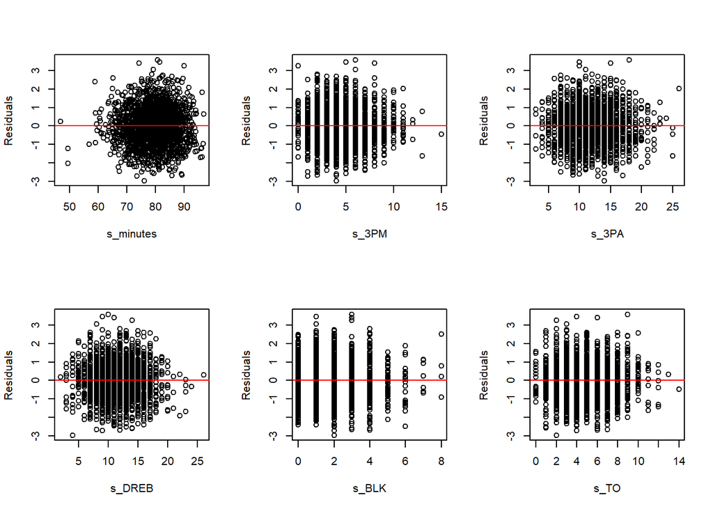

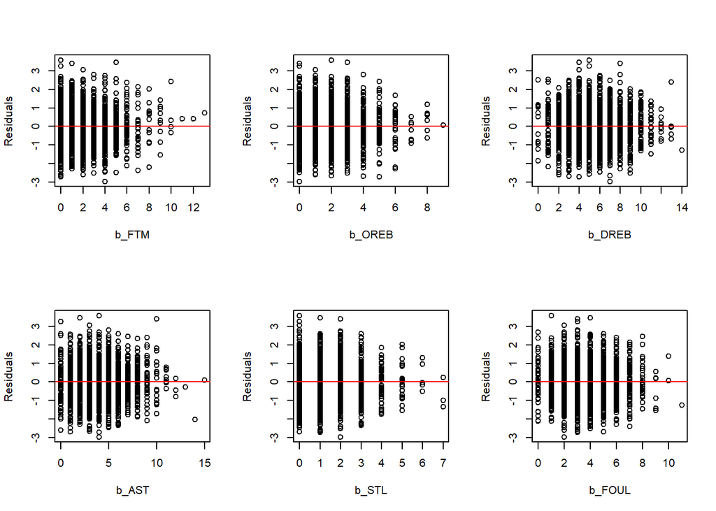

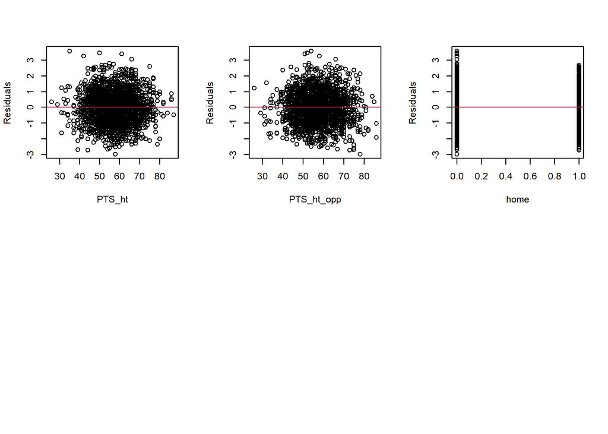

```r
# Residual Analysis
vars = all.vars(formula(model_cp))[-1]

resids = stdres(model_cp)
par(mfrow=(c(2,3)))

for (v in vars) {
  for (i in 1:dim(train)[-1]){
    if (colnames(train[i]) == v){
      plot(train[,i], resids, xlab=v, ylab='Residuals')
      abline(0,0, col='red')
    }
  }
}
```

Variables with obvious constant variance violence: b_FTM, b_OREB, b_STL, home.

Since home is a binary variable, it won’t benefit from transformation. We can try log transformation on other 3 variables.

### Residual Analysis - Response Variable

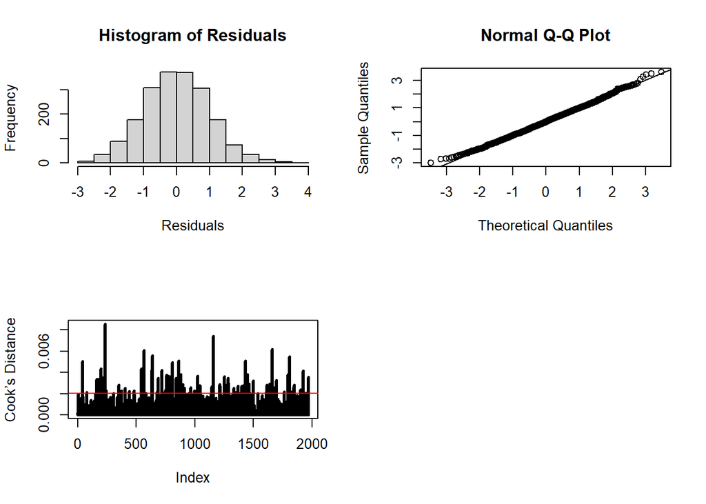

```r
par(mfrow=(c(2,2)))
cook = cooks.distance(model_cp)
hist(resids, xlab="Residuals", main= "Histogram of Residuals")
qqnorm(resids)
qqline(resids)
plot(cook,type="h",lwd=3, ylab = "Cook’s Distance")
abline(h=4/nrow(train), col='red')
```

The residuals follows normal distribution without a heavy tail, and a transformation of the response variable is not needed.

Cook’s Distance may have shown significant number of outliers when using 4/n as the threshold; however, it’s not a good rule of thumb to follow when the number of samples is large. From the plot, we can consider data whose Cook’s Distance is greater than 0.005 to be outliers and build model without them and see if the effects are significant.

### Outlier Analysis

```r
# Refit model without outliers
outliers = cook[cook>0.005]
outliers_index = as.integer(labels(outliers))


model_no_outliers = lm(PTS_final ~ s_minutes+s_3PM+s_3PA+s_DREB+s_BLK+s_TO+b_FTM+b_OREB+
b_DREB+b_AST+b_STL+b_FOUL+PTS_ht+PTS_ht_opp+home, data=train[-c(outliers_index),])

# Compare model coefficients to evaluate the effect of outliers
coef(model_no_outliers)
```

```
## (Intercept)   s_minutes       s_3PM       s_3PA      s_DREB       s_BLK
##  44.2717243  -0.1016244  -0.4073495   0.2219354   0.2298853   0.1770683
##        s_TO       b_FTM      b_OREB      b_DREB       b_AST       b_STL
##   0.1910087  -0.1725554   0.2909434   0.3657780  -0.1875064  -0.2913537
##      b_FOUL      PTS_ht  PTS_ht_opp        home
##   0.1802206   1.0563660   0.1859364   1.0528955
```

```r
coef(model_cp)
```

```
## (Intercept)   s_minutes       s_3PM       s_3PA      s_DREB       s_BLK
## 44.01826056 -0.09286737 -0.37770640  0.21041114  0.23364239  0.20263597
##        s_TO       b_FTM      b_OREB      b_DREB       b_AST       b_STL
##  0.20212270 -0.16931800  0.27601730  0.36843324 -0.17895387 -0.30208871
##      b_FOUL      PTS_ht  PTS_ht_opp        home
##  0.17193770  1.04875442  0.18447810  1.01914309
```

The coefficients are very similar between the 2 models with and without outliers; therefore, we can keep the outliers in the model and we do not need to create separate models.

### Multicollinearity Analysis

```r
# Evaluate multicollinearity
sprintf("VIF threshold is: %i", max(1/summary(model_cp)$r.squared, 10))
```

```
## [1] "VIF threshold is: 10"
```

```r
vif(model_cp)
```

```
##  s_minutes      s_3PM      s_3PA     s_DREB      s_BLK       s_TO      b_FTM
##   1.879283   2.720217   2.237925   1.668563   1.057257   1.165135   1.126451
##     b_OREB     b_DREB      b_AST      b_STL     b_FOUL     PTS_ht PTS_ht_opp
##   1.081699   1.491820   1.427929   1.099332   1.066701   1.784684   1.627658
##       home
##   1.019619
```

All VIF values are less than 3, and multicollinearity is not a concern.

### Perform Transformation

```r
# Transformation of model_cp (b_FTM, b_OREB, b_STL)
model_trans = lm(formula = PTS_final ~ s_minutes + s_3PM + s_3PA + s_DREB +
    s_BLK + s_TO + log(b_FTM+1) + log(b_OREB+1) + b_DREB + b_AST + log(b_STL+1) +
    b_FOUL + PTS_ht + PTS_ht_opp + home, data = train)
summary(model_trans)
```

```
##
## Call:
## lm(formula = PTS_final ~ s_minutes + s_3PM + s_3PA + s_DREB +
##     s_BLK + s_TO + log(b_FTM + 1) + log(b_OREB + 1) + b_DREB +
##     b_AST + log(b_STL + 1) + b_FOUL + PTS_ht + PTS_ht_opp + home,
##     data = train)
##
## Residuals:
##      Min       1Q   Median       3Q      Max
## -26.0543  -6.2502  -0.0655   5.9519  31.4231
##
## Coefficients:
##                 Estimate Std. Error t value Pr(>|t|)
## (Intercept)     43.52870    4.45235   9.777  < 2e-16 ***
## s_minutes       -0.09070    0.04088  -2.219 0.026633 *
## s_3PM           -0.38002    0.14590  -2.605 0.009265 **
## s_3PA            0.21260    0.08386   2.535 0.011317 *
## s_DREB           0.23784    0.07857   3.027 0.002500 **
## s_BLK            0.19932    0.14206   1.403 0.160775
## s_TO             0.20365    0.09775   2.083 0.037347 *
## log(b_FTM + 1)  -0.55545    0.31379  -1.770 0.076864 .
## log(b_OREB + 1)  0.76769    0.37346   2.056 0.039950 *
## b_DREB           0.37672    0.10526   3.579 0.000353 ***
## b_AST           -0.17690    0.10398  -1.701 0.089046 .
## log(b_STL + 1)  -0.56588    0.40253  -1.406 0.159942
## b_FOUL           0.17340    0.11708   1.481 0.138772
## PTS_ht           1.04884    0.02960  35.429  < 2e-16 ***
## PTS_ht_opp       0.18728    0.02864   6.539 7.88e-11 ***
## home             1.02333    0.40258   2.542 0.011101 *
## ---
## Signif. codes:  0 '***' 0.001 '**' 0.01 '*' 0.05 '.' 0.1 ' ' 1
##
## Residual standard error: 8.844 on 1952 degrees of freedom
## Multiple R-squared:  0.5298, Adjusted R-squared:  0.5262
## F-statistic: 146.6 on 15 and 1952 DF,  p-value: < 2.2e-16
```

### Residual Analysis on Transformed Model

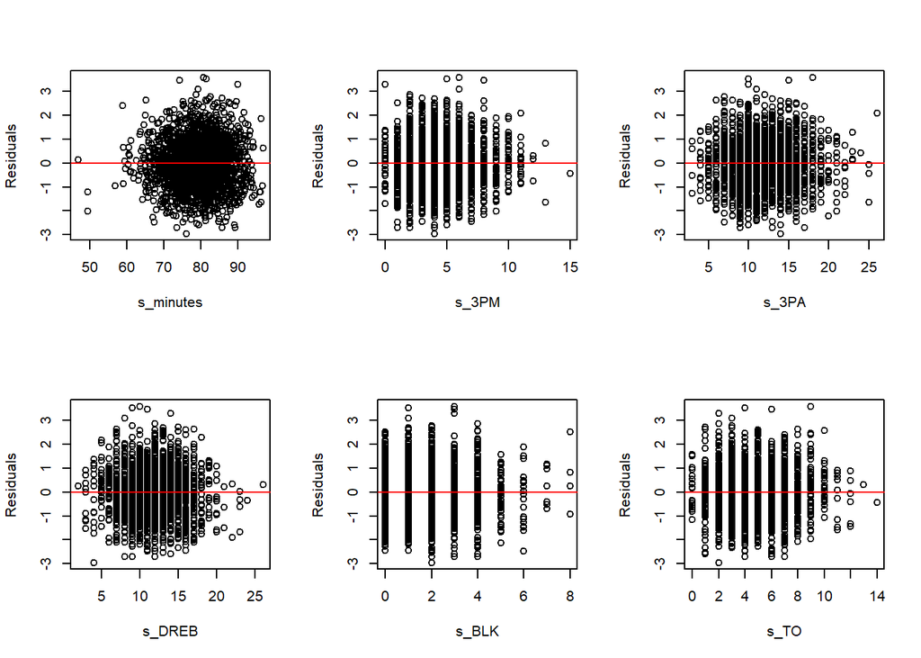

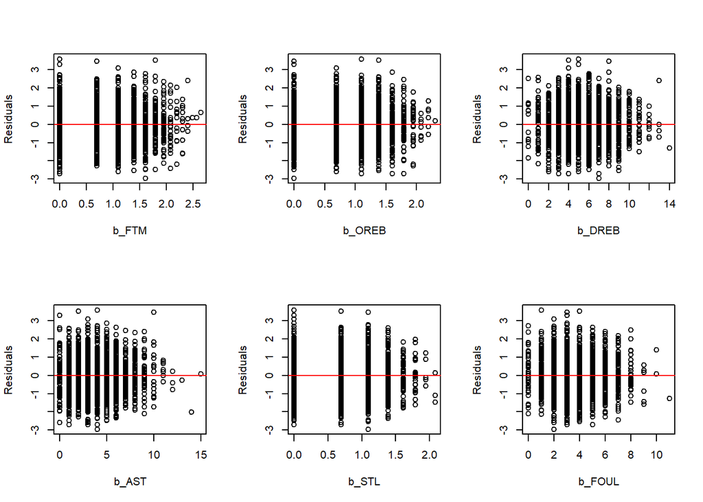

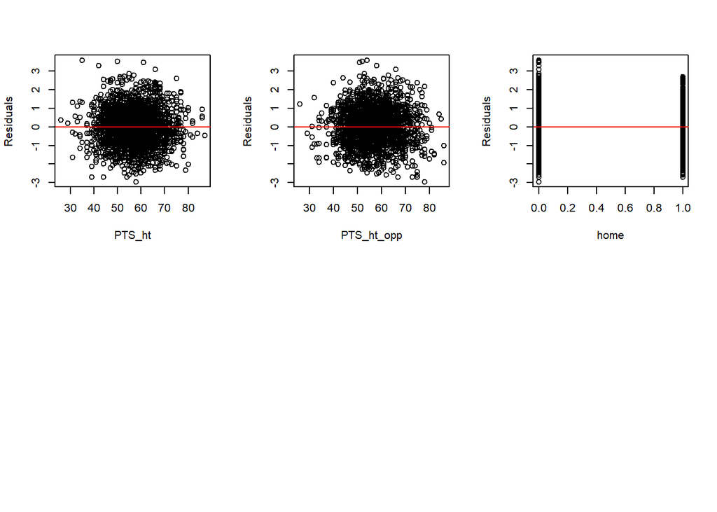

```r
# Residual Analysis (with log transformed b_FTM, b_OREB, b_STL)
vars = all.vars(formula(model_trans))[-1]

resids = stdres(model_trans)
par(mfrow=(c(2,3)))

for (v in vars) {
  for (i in 1:dim(train)[-1]){
    if (colnames(train[i]) == v){
      if (colnames(train[i]) %in% list('b_FTM', 'b_OREB', 'b_STL')){
        plot(log(train[,i]+1), resids, xlab=v, ylab='Residuals')
        abline(0,0, col='red')
      } else {
      plot(train[,i], resids, xlab=v, ylab='Residuals')
      abline(0,0, col='red')
      }
    }
  }
}
```

After transformation, the variances of b_FTM, b_OREB, and b_STL appears to be more of a constant although it’s still not perfect.

### Model Evaluation

#### MSPE & PE

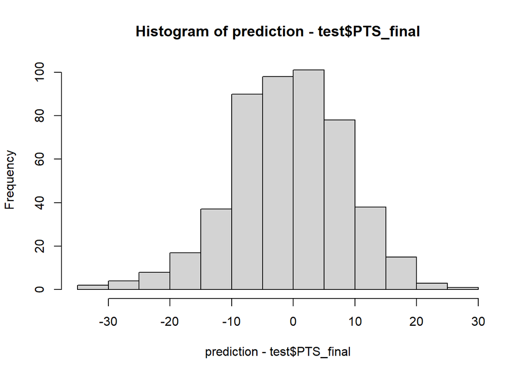

```r
# Use Test data to evaluate its ability to predict final score
prediction = predict(model_trans, test)
hist(prediction-test$PTS_final)
```

```r
y_bar = mean(test$PTS_final)
MSPE = sum((prediction - test$PTS_final) ** 2) / nrow(test)
PE = sum((prediction - test$PTS_final)**2) / sum((test$PTS_final - y_bar)**2)
sprintf("The mean squared prediction error (MSPE) is %f", MSPE)
```

```
## [1] "The mean squared prediction error (MSPE) is 85.490439"
```

```r
sprintf("The Precision error is %f", PE)
```

```
## [1] "The Precision error is 0.519387"
```

#### Prediction Interval

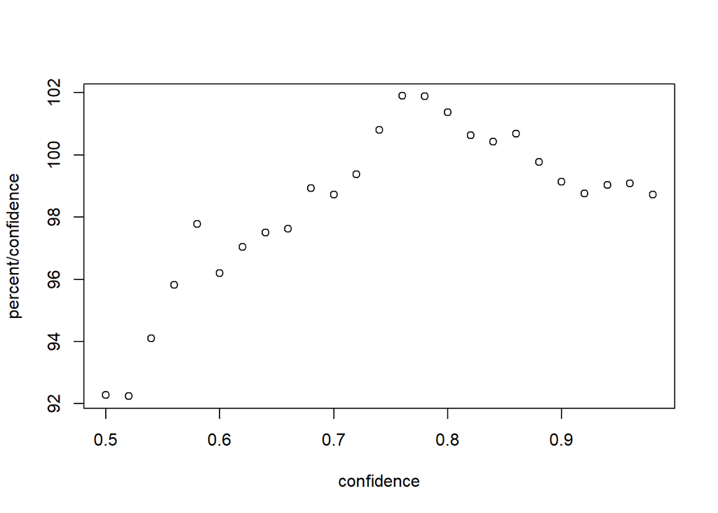

```r
# Evaluate the model using prediction interval
confidence = c()
percent = c()
for (i in seq(0.5, 0.99, 0.02)){
  pred_int = predict(model_trans, test, interval = 'prediction', level=i)
  p = sum(test$PTS_final < pred_int[,3] & test$PTS_final > pred_int[,2]) / nrow(test) * 100
  confidence = c(confidence, i)
  percent = c(percent, p)
}

plot(confidence, percent/confidence)
```

## Conclusion and Future Work

The developed model hopefully has more than 80% accuracy in predicting the final score using box score of both team at halftime. The results can be used to place bet on the score of each team, combined score, or score differential at halftime.

Machine learning can be utilized to improve the model and hopefully narrow the prediction interval to achieve better results.